# Machine Learning Course Project

Toucan15

July 23, 2015

## Introduction

This project uses data from an experiment on activity pattern recognition. Six subjects, each wearing four sensors (forearm, arm, belt, and dumbell), completed dumbell biceps curls in five different ways. Type A was the correct method and types B, C, D, and E were incorrect in slightly different ways. Each sensor recorded 13 variables during the exercises (see list below).

The goal of this project is to devise a machine learning algorithm that can predict the method of the exercise (A, B, C, D, or E). This could be used to develop a trainer program that could provide feedback to a person exercising to improve their technique. The steps used in the algorithm are shown below.

```r
##read in the data
data3 <- read.csv("pml-training.csv", na.strings=c(""," ","NA"))
```

```r
##check for missing values
colSums(is.na(data3))
```

```
##                        X                user_name     raw_timestamp_part_1
##                        0                        0                        0
##     raw_timestamp_part_2           cvtd_timestamp               new_window
##                        0                        0                        0
##               num_window                roll_belt               pitch_belt
##                        0                        0                        0
##                 yaw_belt         total_accel_belt       kurtosis_roll_belt
##                        0                        0                    19216
##      kurtosis_picth_belt        kurtosis_yaw_belt       skewness_roll_belt
##                    19216                    19216                    19216
##     skewness_roll_belt.1        skewness_yaw_belt            max_roll_belt
##                    19216                    19216                    19216
##           max_picth_belt             max_yaw_belt            min_roll_belt
##                    19216                    19216                    19216
##           min_pitch_belt             min_yaw_belt      amplitude_roll_belt
##                    19216                    19216                    19216
##     amplitude_pitch_belt       amplitude_yaw_belt     var_total_accel_belt
##                    19216                    19216                    19216
##            avg_roll_belt         stddev_roll_belt            var_roll_belt
##                    19216                    19216                    19216
##           avg_pitch_belt        stddev_pitch_belt           var_pitch_belt
##                    19216                    19216                    19216
##             avg_yaw_belt          stddev_yaw_belt             var_yaw_belt
##                    19216                    19216                    19216
##             gyros_belt_x             gyros_belt_y             gyros_belt_z
##                        0                        0                        0
##             accel_belt_x             accel_belt_y             accel_belt_z
##                        0                        0                        0
##            magnet_belt_x            magnet_belt_y            magnet_belt_z
##                        0                        0                        0
##                 roll_arm                pitch_arm                  yaw_arm
##                        0                        0                        0
##          total_accel_arm            var_accel_arm             avg_roll_arm
##                        0                    19216                    19216
##          stddev_roll_arm             var_roll_arm            avg_pitch_arm
##                    19216                    19216                    19216
##         stddev_pitch_arm            var_pitch_arm              avg_yaw_arm
##                    19216                    19216                    19216
##           stddev_yaw_arm              var_yaw_arm              gyros_arm_x
##                    19216                    19216                        0
```

[output cut: 53 more lines]

```
##                    19216                        0                    19216
##         avg_roll_forearm      stddev_roll_forearm         var_roll_forearm
##                    19216                    19216                    19216
##        avg_pitch_forearm     stddev_pitch_forearm        var_pitch_forearm
##                    19216                    19216                    19216
##          avg_yaw_forearm       stddev_yaw_forearm          var_yaw_forearm
##                    19216                    19216                    19216
##          gyros_forearm_x          gyros_forearm_y          gyros_forearm_z
##                        0                        0                        0
##          accel_forearm_x          accel_forearm_y          accel_forearm_z
##                        0                        0                        0
##         magnet_forearm_x         magnet_forearm_y         magnet_forearm_z
##                        0                        0                        0
##                   classe
##                        0
```

Variables are either all present or all NA. The variables that are all NA are those that are summaries of the raw data (average, sd, etc).

```r
##remove all NA variables
data3 <- data3[, colSums(is.na(data3)) < 1]
```

Look at structure of remaining variables

```r
str(data3)
```

```
## 'data.frame':    19622 obs. of  60 variables:
##  $ X                   : int  1 2 3 4 5 6 7 8 9 10 ...
##  $ user_name           : Factor w/ 6 levels "adelmo","carlitos",..: 2 2 2 2 2 2 2 2 2 2 ...
##  $ raw_timestamp_part_1: int  1323084231 1323084231 1323084231 1323084232 1323084232 1323084232 1323084232 1323084232 1323084232 1323084232 ...
##  $ raw_timestamp_part_2: int  788290 808298 820366 120339 196328 304277 368296 440390 484323 484434 ...
##  $ cvtd_timestamp      : Factor w/ 20 levels "02/12/2011 13:32",..: 9 9 9 9 9 9 9 9 9 9 ...
##  $ new_window          : Factor w/ 2 levels "no","yes": 1 1 1 1 1 1 1 1 1 1 ...
##  $ num_window          : int  11 11 11 12 12 12 12 12 12 12 ...
##  $ roll_belt           : num  1.41 1.41 1.42 1.48 1.48 1.45 1.42 1.42 1.43 1.45 ...
##  $ pitch_belt          : num  8.07 8.07 8.07 8.05 8.07 8.06 8.09 8.13 8.16 8.17 ...
##  $ yaw_belt            : num  -94.4 -94.4 -94.4 -94.4 -94.4 -94.4 -94.4 -94.4 -94.4 -94.4 ...
##  $ total_accel_belt    : int  3 3 3 3 3 3 3 3 3 3 ...
##  $ gyros_belt_x        : num  0 0.02 0 0.02 0.02 0.02 0.02 0.02 0.02 0.03 ...
##  $ gyros_belt_y        : num  0 0 0 0 0.02 0 0 0 0 0 ...
##  $ gyros_belt_z        : num  -0.02 -0.02 -0.02 -0.03 -0.02 -0.02 -0.02 -0.02 -0.02 0 ...
```

[output cut: 46 more lines]

The first seven columns don’t appear to be useful for the purpose of characterizing the quality of the activity. The procedures for the activities do not have a time component and including the participant as a variable may actually bias the prediction if certain people do the activities in peculiar ways. Removing these results in a dataset comprised of 52 variables from the 4 sensors each recording 13 features, plus the activity method variables (classe).

```r
##remove first seven columns
data3 <- data3[,8:60]
```

## preparing the data for analysis

```r
library(caret)
library(gbm)
library(plyr)
set.seed(815)
```

```r
##partition the data into training and test sets
data3part <-createDataPartition(y=data3$classe, p=.6, list=FALSE)
traindata <- data3[data3part,]
testdata <- data3[-data3part,]
```

```r
##Further split of training data into 2 sets for cross validation
data3part2 <-createDataPartition(y=traindata$classe, p=.5, list=FALSE)
traindata1 <- traindata[data3part2,]
traindata2 <- traindata[-data3part2,]
```

```r
##this section removes highly correlated variables to
##limit potential problems with multicolinearity
descrCorr <- cor(traindata1[,1:52])
highCorr <- findCorrelation(descrCorr, 0.90)
traindata1 <- traindata1[, -highCorr]
##then remove same varibales from second training set and test set
traindata2 <- traindata2[, -highCorr]
testdata <- testdata[, -highCorr]
dim(traindata1)
```

```
## [1] 5889   48
```

```r
dim(traindata2)
```

```
## [1] 5887   48
```

```r
dim(testdata)
```

```
## [1] 7846   48
```

## Exploratory plots

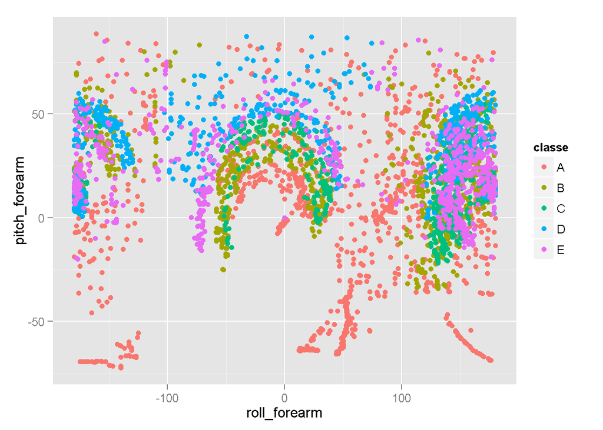

```r
qplot(roll_forearm, pitch_forearm, color=classe, data=traindata1)
```

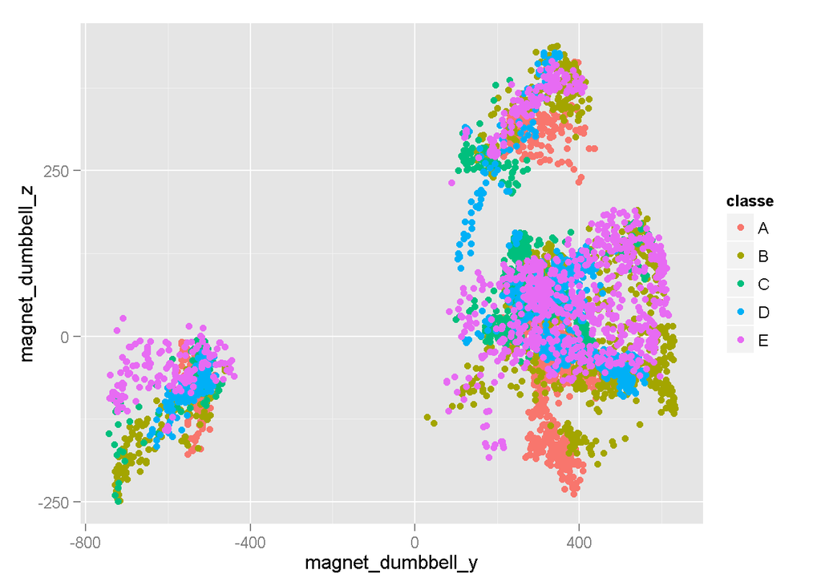

```r
qplot(magnet_dumbbell_y, magnet_dumbbell_z, color=classe, data=traindata1)
```

These plots show patterns among the 5 classes but not straigtforward linear patterns. Thus, regression models will probably not be useful for prediction. Instead I tried random forest and boosting models. Both worked well but the gbm boosting model did slightly better

## The Model

```r
gbmGrid2 <- expand.grid(interaction.depth = (1:5)*2,
                       n.trees = (1:4)*50,
                       shrinkage = .1,
                       n.minobsinnode = 20)
gbmfit2 <- train(classe~., data = traindata1, method = "gbm",
                trControl = trainControl(method = "cv", number = 5),
                verbose = FALSE,
                bag.fraction = 0.5, tuneGrid = gbmGrid2)
```

The expand.grid function allows tuning of the training function to run the code faster. The interaction depth term allows depths up to 10 in steps of 2 rather than all of 1 through 10. The n.trees terms similarly allows trees up to 200 in steps of 50. Shrinkage and minimum number of observations to define a node (n.minobsinnode) were kept constant. In the train function setting trControl to 5 repetitions of cross validation also helps speed the code.

## in sample error

```r
gbmfit2
```

```
## Stochastic Gradient Boosting
##
## 5889 samples
##   47 predictor
##    5 classes: 'A', 'B', 'C', 'D', 'E'
##
## No pre-processing
## Resampling: Cross-Validated (5 fold)
##
## Summary of sample sizes: 4712, 4711, 4711, 4711, 4711
##
## Resampling results across tuning parameters:
##
##   interaction.depth  n.trees  Accuracy   Kappa      Accuracy SD
##    2                  50      0.8356268  0.7917962  0.013360467
##    2                 100      0.8945500  0.8665419  0.012829047
##    2                 150      0.9222291  0.9015984  0.008760421
##    2                 200      0.9347944  0.9174942  0.006495802
##    4                  50      0.9035481  0.8778942  0.011440540
##    4                 100      0.9466801  0.9325470  0.006450117
##    4                 150      0.9599256  0.9492953  0.004172413
##    4                 200      0.9677370  0.9591827  0.002743183
##    6                  50      0.9359831  0.9189839  0.010556399
##    6                 100      0.9602647  0.9497327  0.004221056
##    6                 150      0.9713034  0.9637015  0.004254835
##    6                 200      0.9746996  0.9679953  0.004542479
##    8                  50      0.9507565  0.9376752  0.007221502
##    8                 100      0.9682469  0.9598303  0.005349113
##    8                 150      0.9743602  0.9675650  0.005206956
##    8                 200      0.9755488  0.9690687  0.004995558
##   10                  50      0.9573786  0.9460777  0.004502868
##   10                 100      0.9719824  0.9645611  0.003493974
##   10                 150      0.9762276  0.9699297  0.004066845
##   10                 200      0.9787750  0.9731507  0.004606507
##   Kappa SD
##   0.016844968
##   0.016250769
##   0.011094395
##   0.008215885
##   0.014481784
##   0.008162869
##   0.005286221
##   0.003477577
##   0.013377356
##   0.005342057
##   0.005381520
##   0.005746728
##   0.009151028
##   0.006768787
##   0.006586001
##   0.006318532
##   0.005702126
##   0.004421035
##   0.005145659
##   0.005828526
##
## Tuning parameter 'shrinkage' was held constant at a value of 0.1
##
## Tuning parameter 'n.minobsinnode' was held constant at a value of 20
## Accuracy was used to select the optimal model using  the largest value.
## The final values used for the model were n.trees = 200,
##  interaction.depth = 10, shrinkage = 0.1 and n.minobsinnode = 20.
```

The best model had interaction depth of 10 with 200 trees and had an accuracy of 97.88%

## cross validation

```r
##apply model to second training set
predgbm <- predict(gbmfit2, traindata2)
confusionMatrix(predgbm, traindata2$classe)
```

```
## Confusion Matrix and Statistics
##
##           Reference
## Prediction    A    B    C    D    E
##          A 1664   11    0    0    0
##          B    9 1119   11    0    0
##          C    0    6 1011   11    3
##          D    0    0    4  951    3
##          E    1    3    1    3 1076
##
## Overall Statistics
##
##                Accuracy : 0.9888
##                  95% CI : (0.9858, 0.9913)
##     No Information Rate : 0.2844
##     P-Value [Acc > NIR] : < 2.2e-16
##
##                   Kappa : 0.9858
##  Mcnemar's Test P-Value : NA
##
## Statistics by Class:
##
##                      Class: A Class: B Class: C Class: D Class: E
## Sensitivity            0.9940   0.9824   0.9844   0.9855   0.9945
## Specificity            0.9974   0.9958   0.9959   0.9986   0.9983
## Pos Pred Value         0.9934   0.9824   0.9806   0.9927   0.9926
## Neg Pred Value         0.9976   0.9958   0.9967   0.9972   0.9988
## Prevalence             0.2844   0.1935   0.1745   0.1639   0.1838
## Detection Rate         0.2827   0.1901   0.1717   0.1615   0.1828
## Detection Prevalence   0.2845   0.1935   0.1751   0.1627   0.1841
## Balanced Accuracy      0.9957   0.9891   0.9902   0.9920   0.9964
```

Applying the model to the second training set (cross validation) also has an accuracy of 98.88% with similar accuracy across the categories for the classe variable.

## confusion matrix (out-of-sample error)

```r
##apply model to test set
testpredgbm <- predict(gbmfit2, testdata)
confusionMatrix(testpredgbm, testdata$classe)
```

```
## Confusion Matrix and Statistics
##
##           Reference
## Prediction    A    B    C    D    E
##          A 2222   17    0    0    0
##          B    8 1486   16    0    2
##          C    1   13 1347   13    6
##          D    1    1    5 1272   13
##          E    0    1    0    1 1421
##
## Overall Statistics
##
##                Accuracy : 0.9875
##                  95% CI : (0.9848, 0.9898)
##     No Information Rate : 0.2845
##     P-Value [Acc > NIR] : < 2.2e-16
##
##                   Kappa : 0.9842
##  Mcnemar's Test P-Value : NA
##
## Statistics by Class:
##
##                      Class: A Class: B Class: C Class: D Class: E
## Sensitivity            0.9955   0.9789   0.9846   0.9891   0.9854
## Specificity            0.9970   0.9959   0.9949   0.9970   0.9997
## Pos Pred Value         0.9924   0.9828   0.9761   0.9845   0.9986
## Neg Pred Value         0.9982   0.9949   0.9968   0.9979   0.9967
## Prevalence             0.2845   0.1935   0.1744   0.1639   0.1838
## Detection Rate         0.2832   0.1894   0.1717   0.1621   0.1811
## Detection Prevalence   0.2854   0.1927   0.1759   0.1647   0.1814
## Balanced Accuracy      0.9962   0.9874   0.9898   0.9930   0.9926
```

Applying the model to the test set has similarly high accuracy (98.75%) but slightly lower that for the training set (as expected).

```r
varImp(gbmfit2)
```

```
## gbm variable importance
##
##   only 20 most important variables shown (out of 47)
##
##                   Overall
## yaw_belt           100.00
## pitch_forearm       73.59
## magnet_dumbbell_z   53.27
## magnet_dumbbell_y   44.17
## roll_forearm        41.44
## pitch_belt          41.05
## magnet_belt_z       39.46
## magnet_belt_y       38.52
## gyros_belt_z        34.18
## accel_dumbbell_y    22.56
## accel_forearm_z     20.21
## roll_dumbbell       18.19
## accel_dumbbell_z    17.30
## magnet_forearm_z    15.38
## magnet_forearm_x    15.15
## yaw_arm             15.00
## accel_forearm_x     14.30
## total_accel_belt    12.95
## magnet_arm_z        12.65
## accel_dumbbell_x    10.75
```

# Conclusions

The high accuracy is a bit surprising but reflects the controlled conditions underwhich the data were collected. During the original experiment the participants were carefully instructed how to do the exercises correctly and incorrectly. If the experiment were repeated by having random participants do the exercises without such close supervision, the accuracy would most likely be much lower because the variation among the particiants would be much greater. Nevertheless, this model is a good starting point for the development of such training apps.

## References

The data for this project come from this source: http://groupware.les.inf.puc-rio.br/har.

Velloso, E.; Bulling, A.; Gellersen, H.; Ugulino, W.; Fuks, H. Qualitative Activity Recognition of Weight Lifting Exercises. Proceedings of 4th International Conference in Cooperation with SIGCHI (Augmented Human ’13) . Stuttgart, Germany: ACM SIGCHI, 2013.